# (Ford Go Bike)

## Preliminary Wrangling

- Bay Wheels is a regional public bicycle sharing system in California's San Francisco Bay Area. It is operated by Motivate in a partnership with the Metropolitan Transportation Commission and the Bay Area Air Quality Management District. Bay Wheels is the first regional and large-scale bicycle sharing system deployed in California and on the West Coast of the United States. It was established as Bay Area Bike Share in August 2013. As of January 2018, the Bay Wheels system had over 2,600 bicycles in 262 stations across San Francisco, East Bay and San Jose.
- This data set is taken from https://www.fordgobike.com/system-data and represents trips taken by members of the service for month of February of 2019.
- Data consists of info about trips taken by service's members, their types, their age, their gender, stations of starting and ending trips, duration of trips etc.

```python
df.describe()
```

|  | duration_sec | start_station_id | start_station_latitude | start_station_longitude | end_station_id | end_station_latitude | end_station_longitude | bike_id | member_birth_year |
| --- | --- | --- | --- | --- | --- | --- | --- | --- | --- |
| count | 183412.000000 | 183215.000000 | 183412.000000 | 183412.000000 | 183215.000000 | 183412.000000 | 183412.000000 | 183412.000000 | 175147.000000 |
| mean | 726.078435 | 138.590427 | 37.771223 | -122.352664 | 136.249123 | 37.771427 | -122.352250 | 4472.906375 | 1984.806437 |
| std | 1794.389780 | 111.778864 | 0.099581 | 0.117097 | 111.515131 | 0.099490 | 0.116673 | 1664.383394 | 10.116689 |
| min | 61.000000 | 3.000000 | 37.317298 | -122.453704 | 3.000000 | 37.317298 | -122.453704 | 11.000000 | 1878.000000 |
| 25% | 325.000000 | 47.000000 | 37.770083 | -122.412408 | 44.000000 | 37.770407 | -122.411726 | 3777.000000 | 1980.000000 |
| 50% | 514.000000 | 104.000000 | 37.780760 | -122.398285 | 100.000000 | 37.781010 | -122.398279 | 4958.000000 | 1987.000000 |
| 75% | 796.000000 | 239.000000 | 37.797280 | -122.286533 | 235.000000 | 37.797320 | -122.288045 | 5502.000000 | 1992.000000 |
| max | 85444.000000 | 398.000000 | 37.880222 | -121.874119 | 398.000000 | 37.880222 | -121.874119 | 6645.000000 | 2001.000000 |

## (Visualization 1)

> In this graph, we inspect the distribution of the trip duration accross all users. It appears that most people go for 5-20 minutes rides.

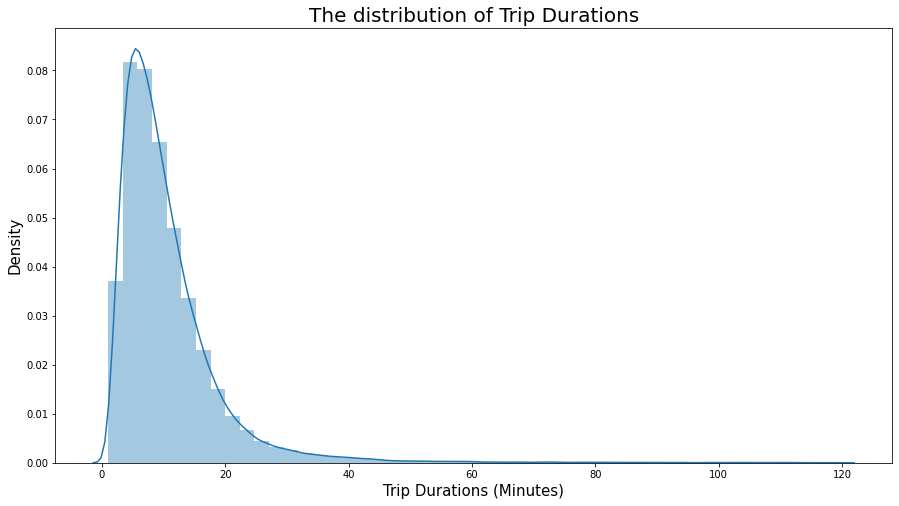

```python
fig, ax = plt.subplots(figsize = (15,8))
sns.distplot(df.duration_min, ax = ax)
plt.xlabel("Trip Durations (Minutes)", fontsize = 15)
plt.ylabel("Density", fontsize = 15)
plt.title("The distribution of Trip Durations", fontsize = 20)
plt.show()
```

## (Visualization 2)

> In this graph, we inspect the distribution of the age duration accross all users. It appears that most people are aged between 20 and 40 years old.

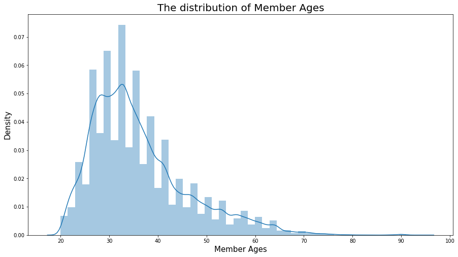

```python
fig, ax = plt.subplots(figsize = (15,8))
sns.distplot(df.member_age, ax = ax)
plt.xlabel("Member Ages", fontsize = 15)
plt.ylabel("Density", fontsize = 15)
plt.title("The distribution of Member Ages", fontsize = 20)
plt.show()
```

## (Visualization 3)

> How many males VS females go for rides? The answer is in this graph, we can see that the men's percentage is much higher!

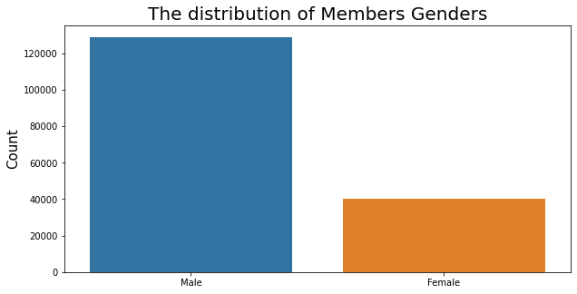

```python
fig, ax = plt.subplots(figsize = (10,5))
sns.countplot(x='member_gender', data=df)
plt.xlabel("")
plt.ylabel("Count", fontsize = 15)
plt.title("The distribution of Members Genders", fontsize = 20)
plt.show()
```

## (Visualization 4)

> In this scatter plot, we can see the relationship between age, trip duration and user type. Younger people seem to be riding for longer times and most people subscribers, not customers!

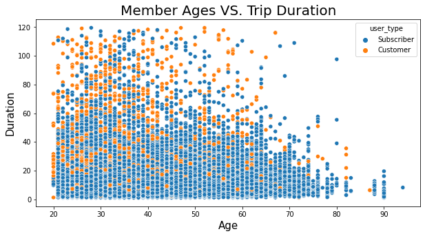

```python
fig, ax = plt.subplots(figsize = (10,5))
sns.scatterplot(x="member_age", y = "duration_min", data = df, hue ="user_type")
plt.title("Member Ages VS. Trip Duration", fontsize = 20)
plt.ylabel("Duration", fontsize = 15)
plt.xlabel("Age", fontsize = 15)
plt.show()
```